# Echantillonnage spatial et temporel chiros

Thibaut Couturier

Analyse en date du 2023-12-20

# Importation, préparation des données

# Sélection 100 sites à Petit rhinolophes

On filtre les données sur 20 ans (2000-2019), on retient les sites avec au moins cinq relevés de Petits rhinolophes au cours de cette période, et au moins un individu contacté. On tire 100 sites selon un échantillonnage pondéré par le log de leur effectif moyen calculé sur 20 ans.

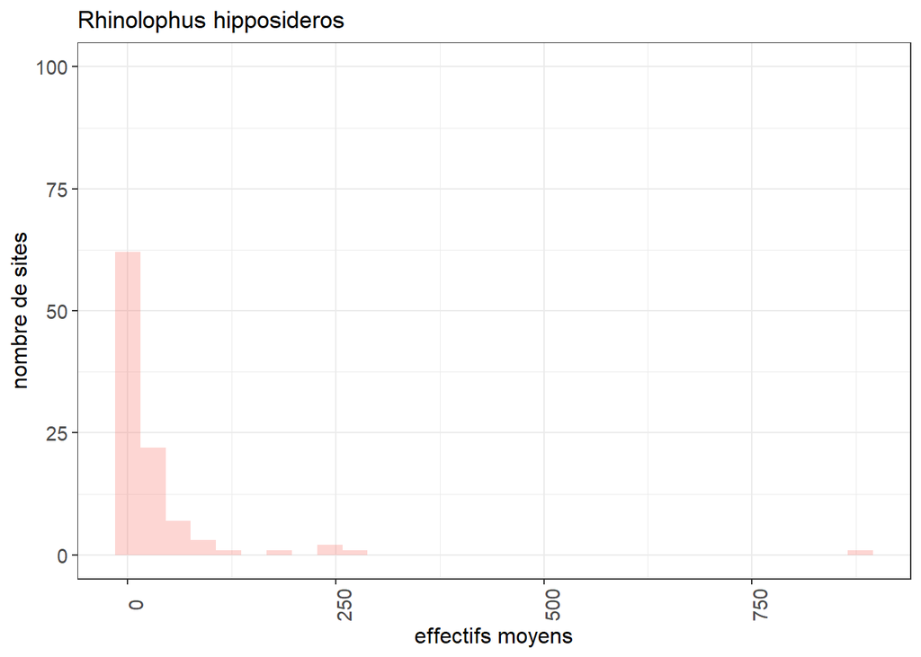

Liste des sites retenus et effectifs moyens en Petits rhinolophes

| CD_SITE | mean |
| --- | --- |
| 91-121212123108CAR | 880.5 |
| 21582.001 | 262.3 |
| 89344.001 | 247.6 |
| 71144.001 | 230.7 |
| 21512.001 | 168.6 |
| 58309.004 | 128.8 |
| 21445.003 | 92.5 |
| 58094.001 | 88.5 |
| 71337.003 | 82.7 |
| 71425.005 | 63.6 |
| 89015.004 | 56.5 |
| 58035.001 | 54.7 |
| 71343.002 | 53.5 |
| 71431.003 | 50.7 |
| 71144.004 | 48.5 |
| 21220.008 | 48.1 |
| 89260.004 | 40.7 |
| 58309.001 | 39.5 |
| 89252.002 | 37.0 |
| 21045.003 | 36.0 |
| 71202.002 | 35.9 |
| EOBS_666 | 32.0 |
| 21635.001 | 32.0 |
| 91-170208102623CAR | 29.0 |
| 71431.001 | 28.4 |
| 71202.004 | 27.1 |
| 58003.001 | 27.1 |
| 91-141218171423CAR | 26.8 |
| 91-170221134533ROB | 23.7 |
| 21361.001 | 21.7 |

[output cut: 70 more lines]

# Effectifs moyens des autres espèces sur ces 100 sites

On récupère les effectifs moyens de chaque espèce obtenus lors de la même période sur ces sites issus de l’échantillonnage “Petit rhinolophe”. On compare avec l’ensemble des sites potentiels pour chaque espèce et avec un tirage basé sur 100 sites (pondérés par l’effectif moyen de chaque espèce).

## Grand rhinolophe

## Grand Murin

## Murin de Daubenton

## Murin de Bechstein

## Murin de Natterer

## Murin à oreilles échancrées

## complexe Murins

## Barbastelle

## Graphe

**Effectifs moyens obtenus pour l’espèce sur les 100 sites “Petits rhinolophes” (rose) et effectifs moyens pour chaque espèce sur l’ensemble des sites potentiels (bleu)**

[figure not shown]

**Effectifs moyens obtenus pour l’espèce sur les 100 sites “Petits rhinolophes” (rose) et tirage de 100 sites par pondération de l’effectif moyen de l’espèce parmi tous les sites potentiels (bleu)**

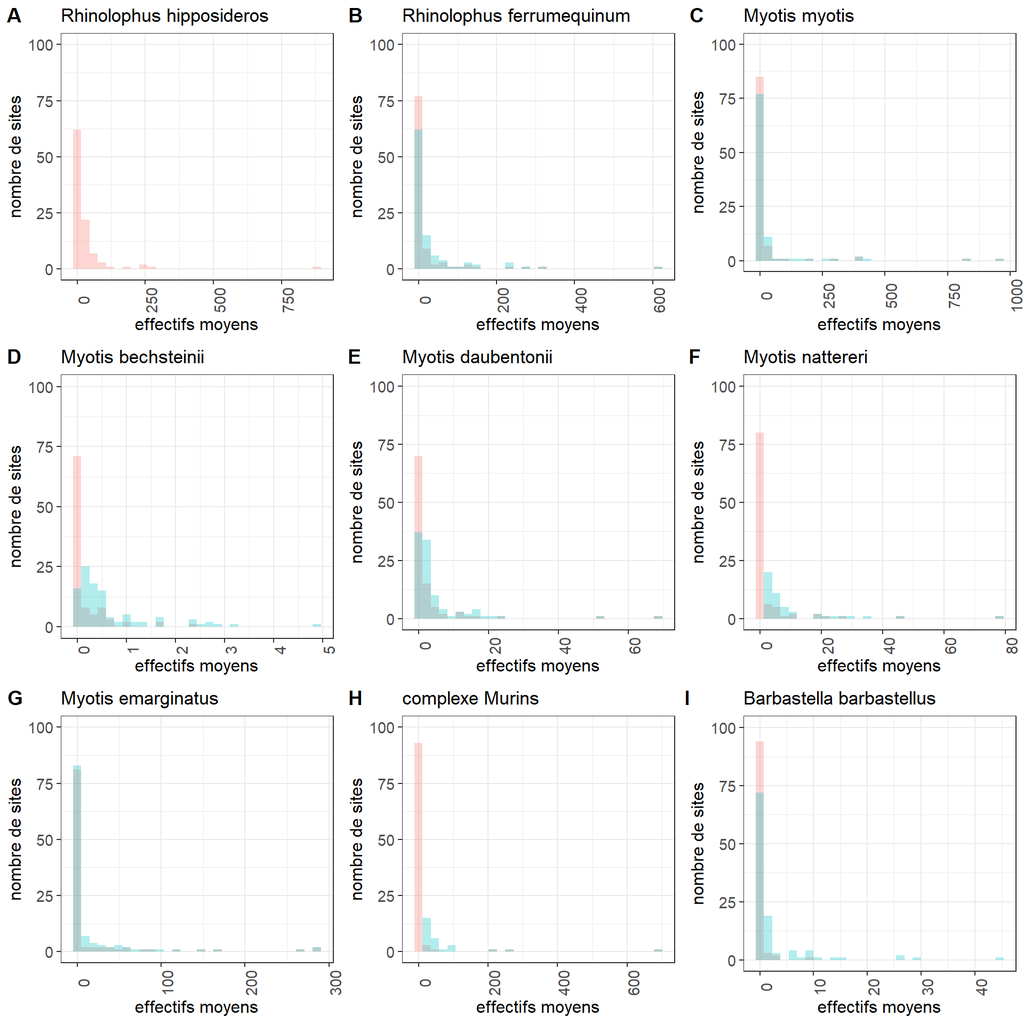

# Mélange 100 sites Petits rhinos et 15 autres sites à forts effectifs pour chaque espèce

On conserve les 100 sites sélectionnés par pondération de la taille pour le Petit rhinolophe. On y ajoute les 15 sites avec les plus forts effectifs moyens pour chaque espèce. On écarte la Barbastelle car tendances impossibles à estimer. On retire à la fin les doublons (sites sélectionnés plusieurs fois pour différentes espèces).

**nombre de sites retenus : n = 127**

## Petit rhinolophe

## Grand rhinolophe

## Grand murin

## Murin de Daubenton

## Murin de Bechstein

## Murin de Natterer

## Murin à oreilles échancrées

## Complexe Murins

## Barbastelle (non utilisé)

## Graphe

Effectif moyen obtenu pour l’espèce sur les 127 sites sélectionnés (rose) et effectifs moyens pour chaque espèce sur l’ensemble des sites potentiels (bleu)

[figure not shown]

## Tableau sites

Liste des 127 sites retenus et effectifs moyens par espèce

| CD_SITE | mean.petit_rhino | mean.grand_rhino | mean_grand_murin | mean_daubenton | mean_bechstein | mean_natterer | mean_echancrees | mean_complexe_murins |
| --- | --- | --- | --- | --- | --- | --- | --- | --- |
| 21013.001 | 21.4 | 155.5 | 396.4 | 22.5 | 0.3 | 0.4 | 145.0 | 3.3 |
| 21017.001 | 3.1 | 0.2 | 0.0 | 0.0 | 0.0 | 0.0 | 0.0 | 0.0 |
| 21044.003 | 4.0 | 0.0 | 0.0 | 0.0 | 0.0 | 0.0 | 0.0 | 0.0 |
| 21045.003 | 36.0 | 6.7 | 12.1 | 0.6 | 0.0 | 0.0 | 54.8 | 2.5 |
| 21051.002 | 3.5 | 6.0 | 4.0 | 2.0 | 0.0 | 0.0 | 0.0 | 0.0 |
| 21061.005 | 10.8 | 17.5 | 0.0 | 0.0 | 0.0 | 0.0 | 0.0 | 0.0 |
| 21071.002 | 4.7 | 0.7 | 0.7 | 0.7 | 0.0 | 0.0 | 0.0 | 0.0 |
| 21122.001 | 9.0 | 1.3 | 0.7 | 0.0 | 0.0 | 0.0 | 0.3 | 1.7 |
| 21210.005 | 2.0 | 0.0 | 0.0 | 0.0 | 0.0 | 0.0 | 0.0 | 0.0 |
| 21220.008 | 48.1 | 3.0 | 0.5 | 0.7 | 0.1 | 0.8 | 0.1 | 0.1 |
| 21226.002 | 1.5 | 60.8 | 4.6 | 1.0 | 0.0 | 0.4 | 2.1 | 93.6 |
| 21226.004 | 0.9 | 0.2 | 5.7 | 5.1 | 0.0 | 1.2 | 1.1 | 42.2 |
| 21339.001 | 1.0 | 0.0 | 0.0 | 0.0 | 0.0 | 0.0 | 0.0 | 0.0 |
| 21361.001 | 21.7 | 2.0 | 10.0 | 0.7 | 0.0 | 0.0 | 0.0 | 0.0 |
| 21373.001 | 4.3 | 222.6 | 1.9 | 1.5 | 0.0 | 0.3 | 1.0 | 0.4 |
| 21412.001 | 16.6 | 2.6 | 2.9 | 0.2 | 0.0 | 0.9 | 0.5 | 0.0 |
| 21445.003 | 92.5 | 0.0 | 0.0 | 0.5 | 0.0 | 0.0 | 0.0 | 0.5 |
| 21462.001 | 1.7 | 1.1 | 8.5 | 7.5 | 2.7 | 5.2 | 14.7 | 15.6 |
| 21464.002 | 0.8 | 0.1 | 0.4 | 0.2 | 0.0 | 0.0 | 0.0 | 0.0 |
| 21464.003 | 3.2 | 1.0 | 0.5 | 0.1 | 0.0 | 0.2 | 0.0 | 0.0 |
| 21478.001 | 7.5 | 0.5 | 2.5 | 0.5 | 0.5 | 0.0 | 0.0 | 253.5 |
| 21478.003 | 1.6 | 0.0 | 3.6 | 0.9 | 0.0 | 0.6 | 0.0 | 0.1 |
| 21485.001 | 2.2 | 14.2 | 43.3 | 1.4 | 0.1 | 0.2 | 0.5 | 0.3 |
| 21512.001 | 168.6 | 10.1 | 49.2 | 1.1 | 0.1 | 0.4 | 3.5 | 0.0 |
| 21541.001 | 10.5 | 0.5 | 0.5 | 0.0 | 0.0 | 0.5 | 0.0 | 0.0 |
| 21541.003 | 5.0 | 0.0 | 1.2 | 0.2 | 0.0 | 0.0 | 0.0 | 0.0 |
| 21578.002 | 6.0 | 0.2 | 2.5 | 1.0 | 0.1 | 0.2 | 0.0 | 0.2 |
| 21578.003 | 6.5 | 0.0 | 1.0 | 0.5 | 0.0 | 0.5 | 1.0 | 0.0 |
| 21582.001 | 262.3 | 81.9 | 197.6 | 6.6 | 0.4 | 6.6 | 39.4 | 1.7 |
| 21635.001 | 32.0 | 0.0 | 0.0 | 0.0 | 0.0 | 0.0 | 0.0 | 0.5 |

[output cut: 97 more lines]